# Project 2 phase 2

Katarzyna Kańska, Annanina Koster, Emilia Pompe

January 7, 2016

# Introduction

The second phase of this project is about improving the model found in phase 1. All three studies will now be used. It will focus on finding out which factors affect the length of dendritic spines of mice and how these factors can best be modeled.

Once again the dataset `dendriticSpines.rda` is used. This time the complete dataset has `38182` observations of `24` mice’s dendritic spines lengths divided over 3 different studies, 3 different mouse types and 5 different types of treatment.

```r
load("dendriticSpines.rda")
dendritic.data <- dendriticSpines
```

The available variables (and their summaries) in this dataset are

```
##      Animal      Photo_ID_abs     spine_number        length
##  Min.   :   1   Min.   :  1.00   Min.   :  1.00   Min.   :0.1096
##  1st Qu.:   3   1st Qu.: 33.00   1st Qu.: 26.00   1st Qu.:0.4200
##  Median :   5   Median : 64.00   Median : 54.00   Median :0.6300
##  Mean   :2571   Mean   : 71.91   Mean   : 68.26   Mean   :0.7354
##  3rd Qu.:7533   3rd Qu.:109.00   3rd Qu.: 92.00   3rd Qu.:0.9240
##  Max.   :7671   Max.   :167.00   Max.   :418.00   Max.   :5.3652
##     Study       mouse       treatment
##  chiron:12954   KO: 3066   -     : 2916
##  gm    :18716   TG:16159   chiron: 6158
##  ko    : 6512   WT:18957   dmso  :15718
##                            gm    : 9794
##                            li    : 3596
##
```

The detailed description of mouse types and the way of measuring the dendritic spine lengths is available in the report oo the first phase.

# The research objective

The research objective in phase 2 is to determine which variables influence the length of dendritic spines of mice significantly in all 3 studies. To do so we need to find the best way to model these variables.

# Results

## Fixed effects

[output not shown]

Signif. codes: 0 `***` 0.001 `**` 0.01 `*` 0.05 `.`

## Random effects

| Variable name | Effect (Std.Dev.) |
| --- | --- |
| `Study:Photo_ID_abs` | 0.09939 |
| `Animal` | 0.09541 |
| `Amimal:chiron` | 0.10739 |
| `Amimal:dmso` | 0.08900 |
| `Amimal:gm` | 0.12583 |
| `Amimal:li` | 0.10311 |

# Statictical methods

## Basic analysis

### Dependent variable `length`

Instead of the variable `length`, we will again use `log(length)` in this phase as the dependent variable. This choice can be justified for example by the histograms below (`log(length)` seems to be closer to the normal distribution).

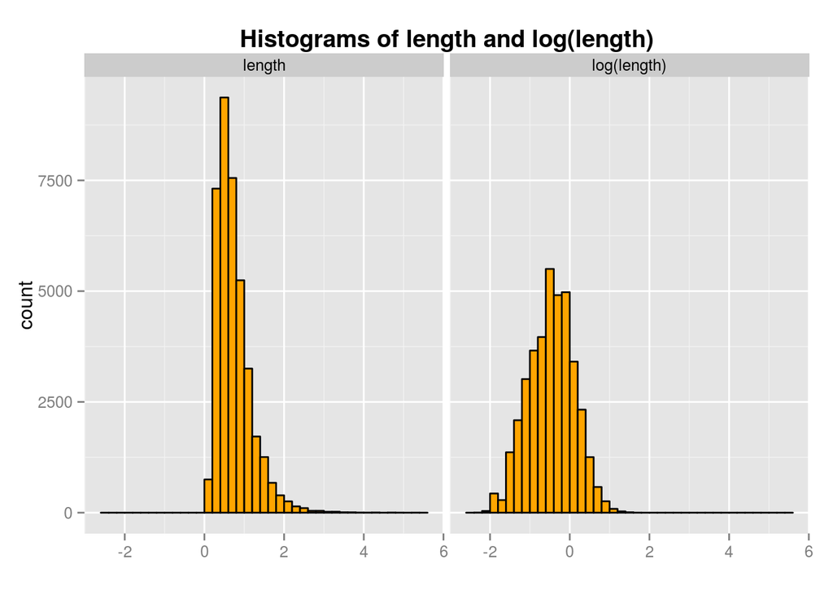

### Explanatory variables `Study`, `mouse`, `treatment`, `Animal`

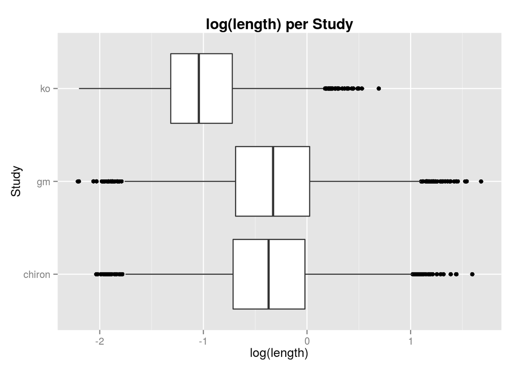

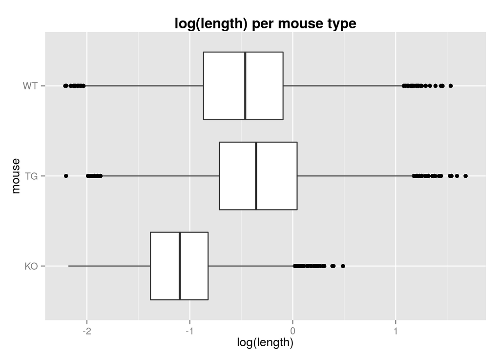

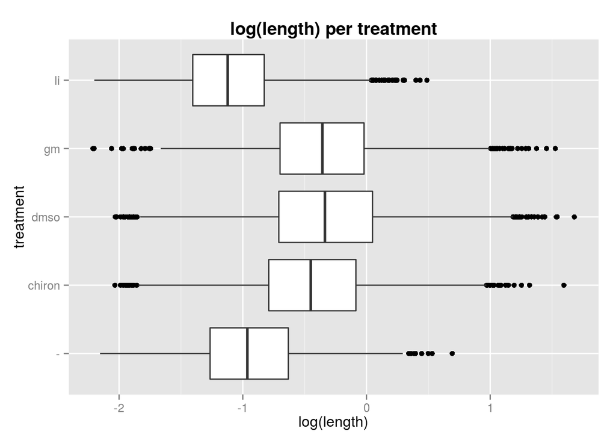

[figure not shown]

The above plots show that all of the variables `Study`, `mouse`, `treatment` and `Animal` may influence the length of spines.

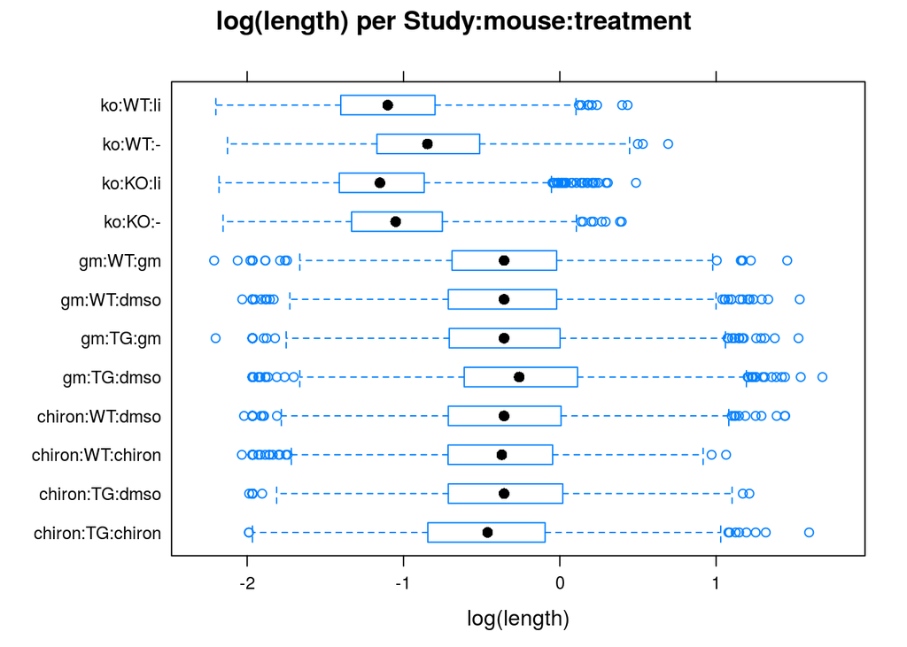

Here we see that study `ko` seems to make the biggest difference in spine’s length. The effects of `mouse` and `treatment` also differ the length of spine’s but their effect is much smaller compared to he effect of `ko` study.

### Interactions and correlation

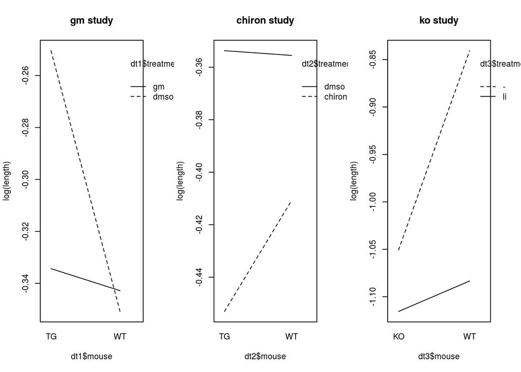

Non of these lines on the interaction plots are parallel, which might suggest that there exists an interaction between `mouse` and `treatment` variables.

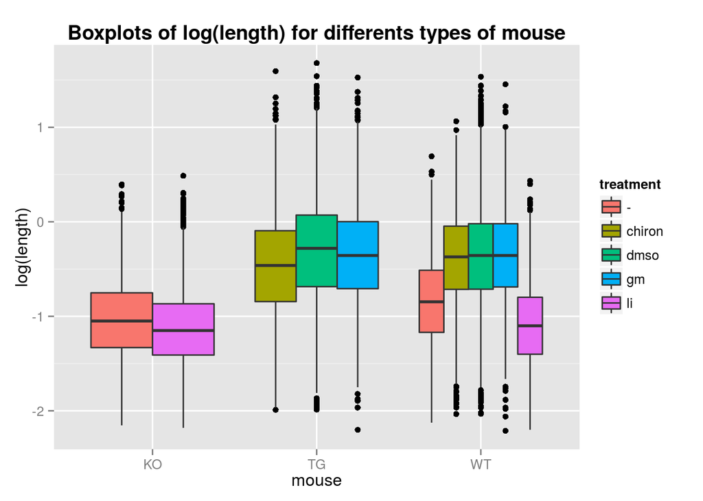

On the above plot we firstly notice that not every treatment is used for every type of mouse. To further measurement of the interaction between treatment and the type of mouse we plot a slightly different graph.

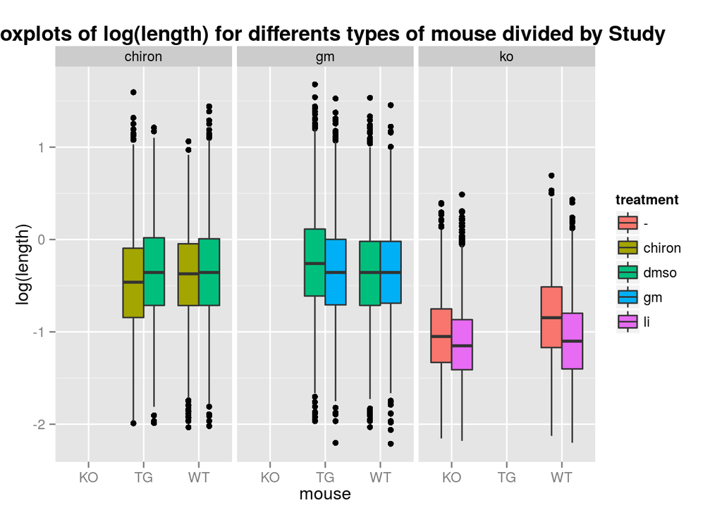

Here we see that within `ko` and `gm` studies there is an interaction between mouse type and treatment, which is less visible within `chiron` study.

For better undertanding what is really the `Study` variable and how it is conneted with variables `mouse`, `treatment` and `Animal`, we examine the following tables.

```
##         mouse
## Study      KO   TG   WT
##   chiron    0 6926 6028
##   gm        0 9233 9483
##   ko     3066    0 3446
```

```
##         treatment
## Study       - chiron dmso   gm   li
##   chiron    0   6158 6796    0    0
##   gm        0      0 8922 9794    0
##   ko     2916      0    0    0 3596
```

```
##      chiron   gm  ko  KO   TG   WT
## 1         0 3263 526   0 1894 1895
## 2         0 3293 470   0 2042 1721
## 3         0 4383 519   0 1995 2907
## 4         0 2977 371   0 1858 1490
## 5         0 4800 571   0 1444 3927
## 6         0    0 446 446    0    0
## 7         0    0 506 506    0    0
## 8         0    0 533 533    0    0
## 9         0    0 521 521    0    0
## 10        0    0 473   0    0  473
## 11        0    0 516   0    0  516
## 13        0    0 250 250    0    0
## 14        0    0 347 347    0    0
## 15        0    0 463 463    0    0
## 7497   1083    0   0   0    0 1083
## 7498   1016    0   0   0    0 1016
## 7532   1099    0   0   0    0 1099
## 7533   2176    0   0   0    0 2176
## 7537    654    0   0   0    0  654
## 7569   1296    0   0   0 1296    0
## 7570   1029    0   0   0 1029    0
## 7571   1587    0   0   0 1587    0
## 7660   1538    0   0   0 1538    0
## 7671   1476    0   0   0 1476    0
```

We can make the following observations:

- Mice of type `KO` appeared only in `ko` study. In other cases the mouse type does not determine the study it was used in.
- Only `dmso` treatment was used in two different studies. The other types of treatment determine the study it was used in.
- Except for the animals 1-5, the animal number determine the study.
- Each animal can have maximum of two different types. Only `KO` type determines the animal number.

As we can see, connections between these variables are very complex. Therefore we will consider several different ideas for modeling such a structure.

### `Photo_ID_abs` variable

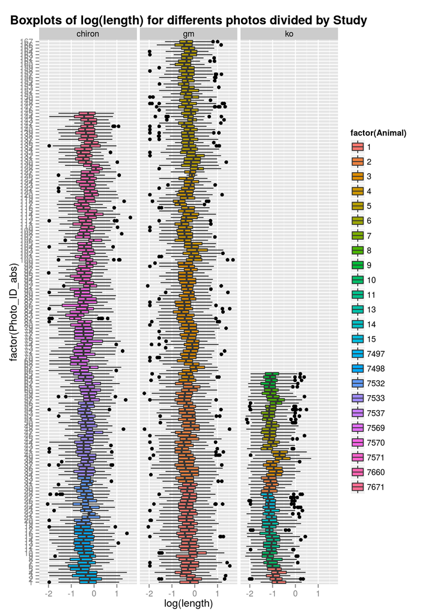

Here we see two things. Firstly, median of spines’ length vary among different photos. Secondly, numbers of photos are overlapping, which means that we have more than one photo with number 1, 2 and so on. Moreover, animal number in `chiron` and `gm` studies are not overlapping. This leads us to the conclusion that `Photo_ID_abs` should be treated as a **nested effect** (photo no. 1 in `chiron` study is definitely not he same photo which has no.1 in `gm` study because the animal is not the same).

To figure out whether `Photo_ID_abs` is a nested in `Study` or in `Animal` effect, we have to look carefully at photos of animals with number from 1 to 5.

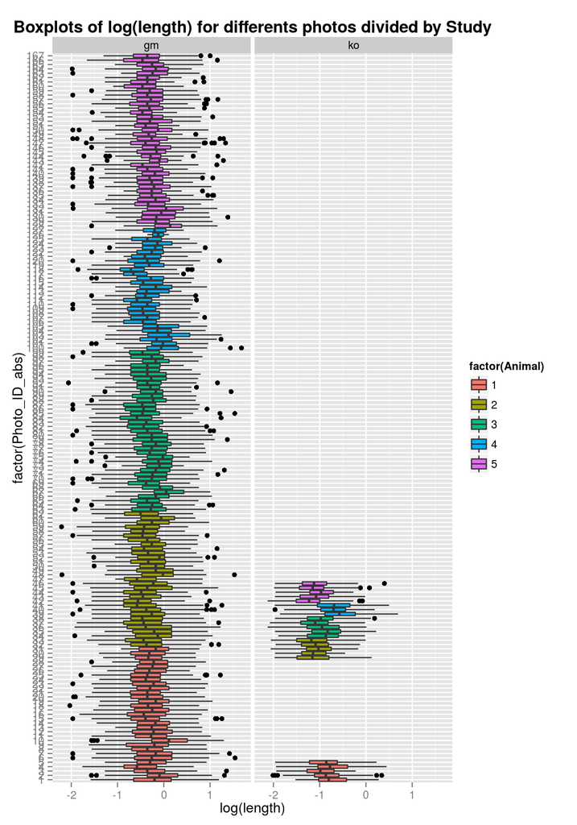

Is the photo no. 1 the same photo used in two different studies? Let us see the number of spines on each of them.

```
##      Photo_ID_abs
## Study   1   2   3   4   5
##    gm 135 138  48  99 117
##    ko  88 132  95 119  92
```

These are different photos. Finally, we come up with the conclusion that the effect of `Photo_ID_abs` is nested in the `Study` effect.

## Model Selection

To start with, let us sum up what we know about available variables from basic analysis.

[output not shown]

### Transformation of dependent variable `length`

We perform the Box-Cox transformation for a very simple linear model considering only `mouse` and `treatment`.

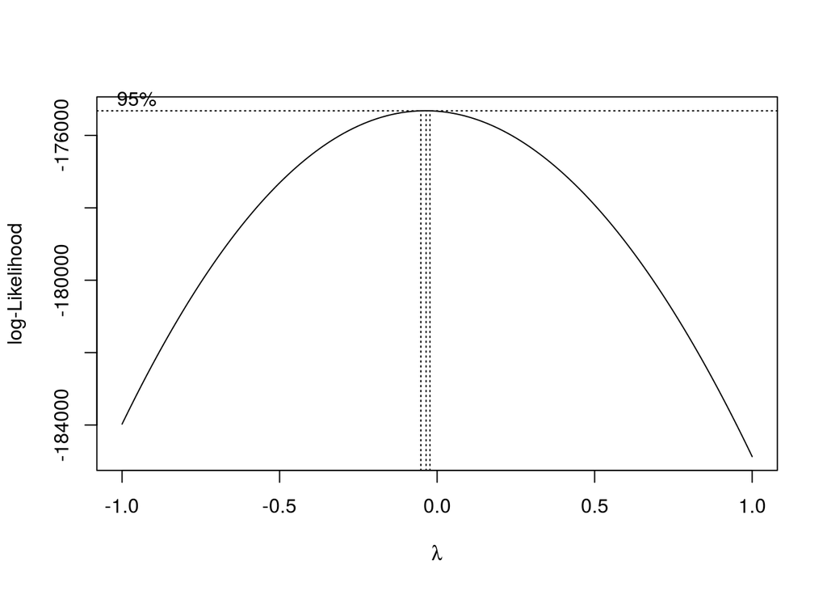

```
## [1] -0.035
```

The optimal parameter is close to zero, so we use the logarithm transformation.

### Checking for interactions between `mouse` and `treatment`

Models 1.0 and 1.1 use `Study` only to distinguish the effect of the photo. This variable is not used on its own as it seems to repeat the information provided by `mouse` and `treatment` variables. Both `Aminal` and `Photo_ID_abs` are modeled as random effects. Variables `mouse` and `treatment` are treated as fixed effects. Model 1.1 additionally consider interaction between these two.

```
## Data: dendritic.data
## Models:
## model1.0: log(length) ~ mouse + treatment + (1 | Animal) + (1 | Study:Photo_ID_abs)
## model1.1: log(length) ~ mouse * treatment + (1 | Animal) + (1 | Study:Photo_ID_abs)
##          Df   AIC   BIC logLik deviance  Chisq Chi Df Pr(>Chisq)
## model1.0 10 54754 54839 -27367    54734
## model1.1 13 54745 54856 -27360    54719 14.606      3   0.002186 **
## ---
## Signif. codes:  0 '***' 0.001 '**' 0.01 '*' 0.05 '.' 0.1 ' ' 1
```

Model 1.1 seems to be slightly better than model 1.0.

### Modelling the effect of `Animal`

In this section we examine two ideas for modeling the effect of `Animal`: changing it from random to fixed and taking into consideration that different animals may react differently for each treatment (which is often the case with humans).

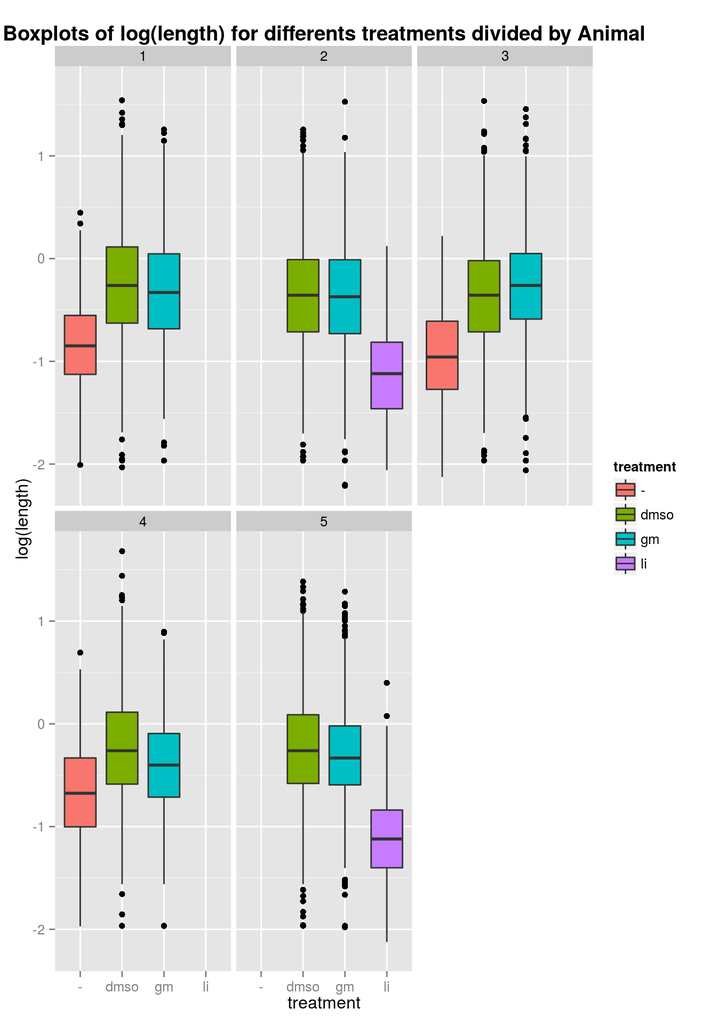

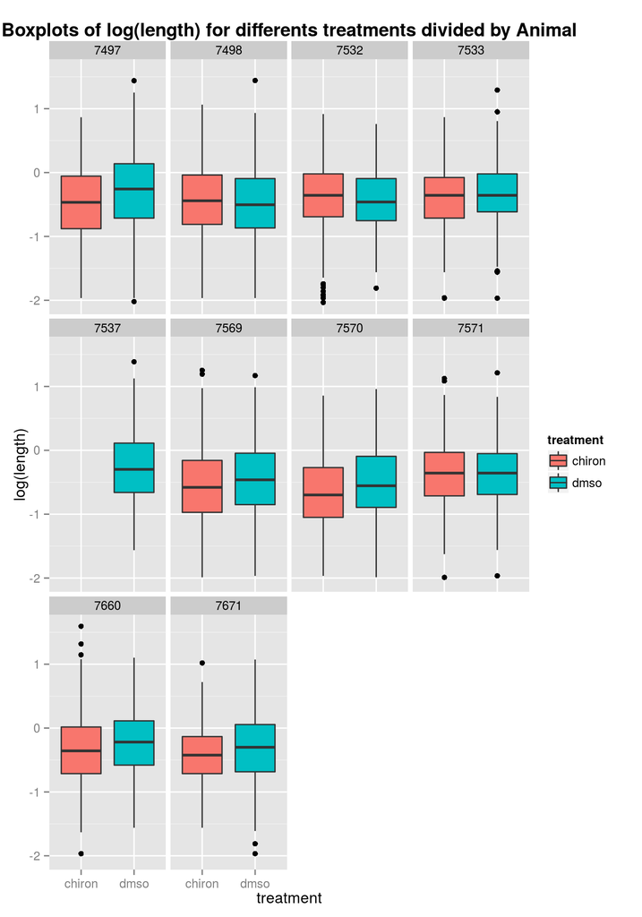

Firstly, we again check for interactions between `mouse` and `treatment`.

```
## Data: dendritic.data
## Models:
## model2.0: log(length) ~ mouse + treatment + (treatment | Animal) + (1 |
## model2.0:     Study:Photo_ID_abs)
## model2.1: log(length) ~ mouse * treatment + (treatment | Animal) + (1 |
## model2.1:     Study:Photo_ID_abs)
##          Df   AIC   BIC logLik deviance  Chisq Chi Df Pr(>Chisq)
## model2.0 24 54759 54964 -27355    54711
## model2.1 27 54749 54980 -27348    54695 15.639      3   0.001344 **
## ---
## Signif. codes:  0 '***' 0.001 '**' 0.01 '*' 0.05 '.' 0.1 ' ' 1
```

```
## Data: dendritic.data
## Models:
## model3.0: log(length) ~ mouse + treatment + factor(Animal) + (1 | Study:Photo_ID_abs)
## model3.1: log(length) ~ mouse * treatment + factor(Animal) + (1 | Study:Photo_ID_abs)
##          Df   AIC   BIC logLik deviance  Chisq Chi Df Pr(>Chisq)
## model3.0 31 54732 54997 -27335    54670
## model3.1 33 54723 55005 -27328    54657 13.503      2   0.001169 **
## ---
## Signif. codes:  0 '***' 0.001 '**' 0.01 '*' 0.05 '.' 0.1 ' ' 1
```

In both cases still the interaction seems to be significant.

### Comparison of models

Now we compare models with interaction using AIC and BIC criteria.

```
##               AIC      BIC
## model1.1 54797.89 54909.04
## model2.1 54801.75 55032.60
## model3.1 54877.33 55159.48
```

Both BIC and AIC suggest that model1.1 is the best.

To confirm this result we compare the normality of residuals and random effects to check the model assumptions.

Here we present the table with p-values from Jarque-Bera and Shapiro-Wilk test for normality.

```
##          residuals Study:Photo_ID_abs Animal(mean)
## model1.1 0.5926473          0.7859376  0.001212046
## model2.1 0.5912983          0.7715410  0.386172861
## model3.1 0.6038145          0.8290798           NA
```

Model 1.1 fails to fulfill assumption about normality of `Animal` random effect. So we choose the second best model (considering BIC), that is model 2.1.

## Model validation

### Normality of random effects

There are 4 random effect left to be tested for normality.

```
##
##  Shapiro-Wilk normality test
##
## data:  ranef(model2.1, condVar = TRUE)$Animal$treatmentchiron
## W = 0.95505, p-value = 0.3472
```

```
##
##  Shapiro-Wilk normality test
##
## data:  ranef(model2.1, condVar = TRUE)$Animal$treatmentdmso
## W = 0.9618, p-value = 0.4756
```

```
##
##  Shapiro-Wilk normality test
##
## data:  ranef(model2.1, condVar = TRUE)$Animal$treatmentgm
## W = 0.94939, p-value = 0.2628
```

```
##
##  Shapiro-Wilk normality test
##
## data:  ranef(model2.1, condVar = TRUE)$Animal$treatmentli
## W = 0.96005, p-value = 0.4394
```

These assumptions are met. To be convinced, let us see the empirical distribution function for `Photo_ID_abs`.

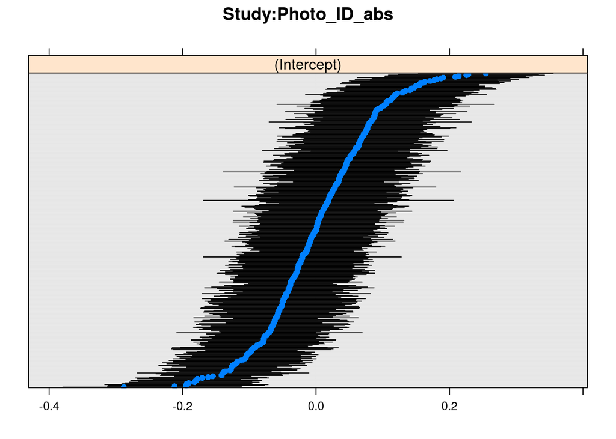

The plot for `Photo_ID_abs` is very similar to the normal cumulative distribution function.

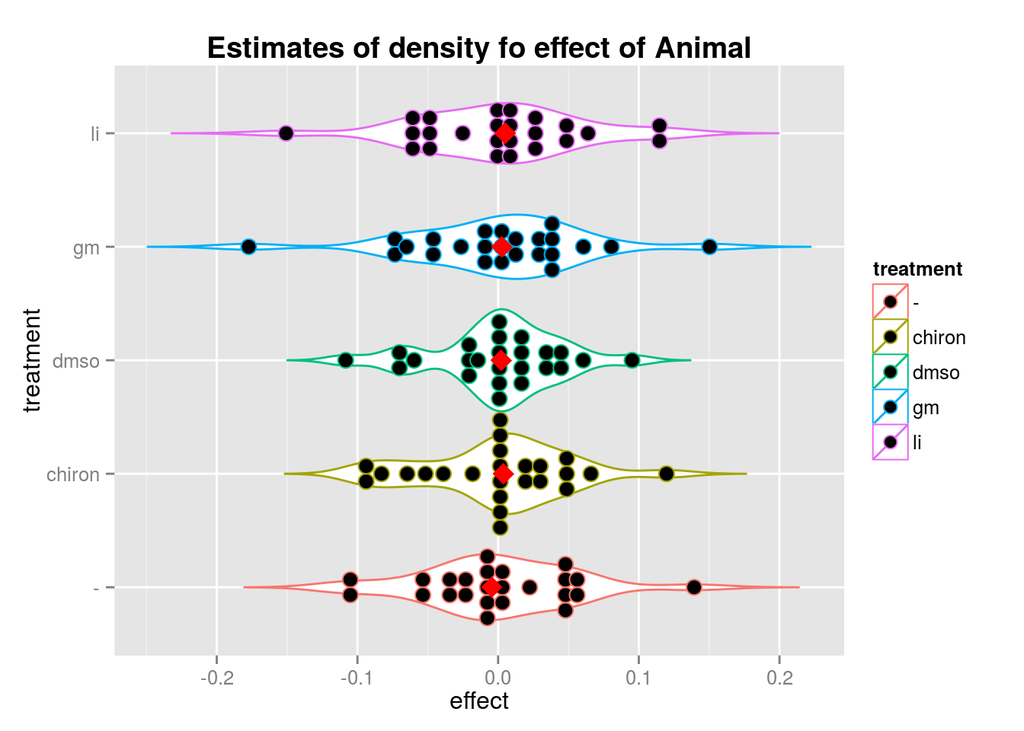

Most of these plots are symmetric.

### Normality of residuals

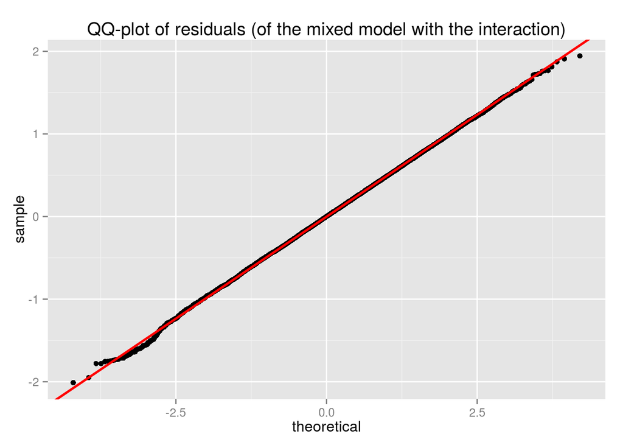

The QQ plot indicates that residuals are normally distributed.

### Homogenity of variance for residuals

```
##    mouse treatment       var
## 1     KO         - 0.1968164
## 2     KO        li 0.1909424
## 3     TG    chiron 0.2563637
## 4     TG      dmso 0.2656138
## 5     TG        gm 0.2399614
## 6     WT         - 0.2051313
## 7     WT    chiron 0.2528295
## 8     WT      dmso 0.2512274
## 9     WT        gm 0.2166794
## 10    WT        li 0.1931231
```

The variances calculated for groups seem to be quite similar (vary from 0.19 to 0.26).

### Independence of epsilons and random effects

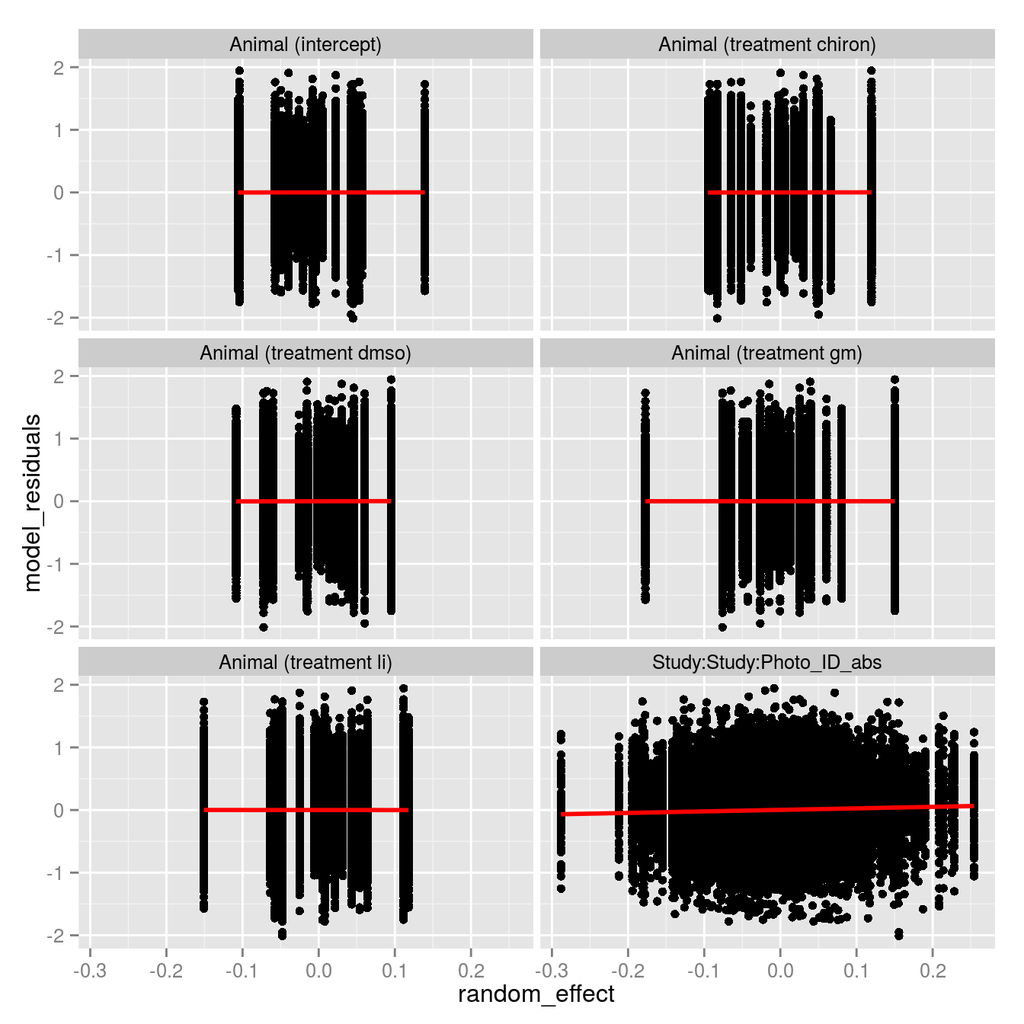

```r
u <- ranef(model2.1, condVar = TRUE)
e <- residuals(model2.1)
# v contains  random effects for Animal
v <- u$Animal[paste0(dendritic.data$Animal),]

# w contains a 'nested' random effect for Study:Photo
w <- u$'Study:Photo_ID_abs'[paste0(dendritic.data$Study,":",dendritic.data$Photo_ID_abs),1]

d <- data.frame(model_residuals=c(e,e,e,e,e,e), random_effect=c(v[,1],v[,2],v[,3],v[,4], v[,5],w),
                type=rep(c("Animal (intercept)", "Animal (treatment chiron)",
                           "Animal (treatment dmso)", "Animal (treatment gm)",
                           "Animal (treatment li)",
                           "Study:Study:Photo_ID_abs"), each=nrow(dendritic.data)))
ggplot(d, aes(x=random_effect, y=model_residuals)) + geom_point() + geom_smooth(method="lm", col="red", size=1)+
  facet_wrap(~type, ncol=2)
```

Epsilons and random effects seem to be independent as we cannot see any pattern in these plots.

### Wald test for fixed effects

```
##         (Intercept)         treatmentli mouseWT:treatmentli
##        2.774317e-63        3.394034e-01        4.137106e-02
```

```
##                 mouseTG                 mouseWT         treatmentchiron
##            5.742282e-03            7.521950e-03            6.709482e-11
##           treatmentdmso             treatmentgm mouseTG:treatmentchiron
##            5.185581e-16            1.239148e-13            9.121199e-01
##   mouseTG:treatmentdmso
##            2.015235e-03
```

All of the coefficients are significant except the 3 following: treatmentli, mouseWT:treatmentli and mouseTG:treatmentchiron at the significance level 0.01. However we did not remove them from the model, as only some levels of the variable are insignificant. In general, all variables (but not all levels) turned out to be significant.

### Significance of mixed effects

We compare Log Likelihoods for models with and without random effects (and with one of the two used random effects).

```
## [1] 3.100869e-278
```

```
## [1] 4.062397e-163
```

```
## [1] 2.102729e-07
```

```
## [1] 0
```

All the differences turned out to be significant. It means that both of our random effects: treatment|Animal and 1|Study:Photo_ID_abs are significant.

### Correlation structure

**Fixed effects**

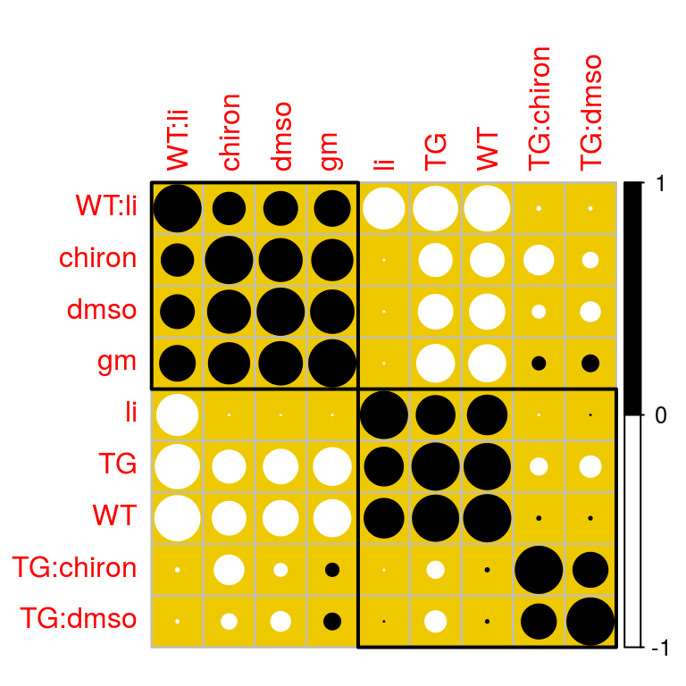

[figure not shown]

**Random effects**

```
##  Groups             Name            Std.Dev. Corr
##  Study:Photo_ID_abs (Intercept)     0.099387
##  Animal             (Intercept)     0.095413
##                     treatmentchiron 0.107392 -0.630
##                     treatmentdmso   0.088995 -0.508  0.934
##                     treatmentgm     0.125835 -0.977  0.769  0.681
##                     treatmentli     0.103114 -1.000  0.619  0.494  0.973
##  Residual                           0.491224
```

Both fixed and random effects are correlated. This was inevitable knowing the structure of the data.

## Summary

Here we present the final model, which fulfills all assumptions.

```
## Linear mixed model fit by REML ['lmerMod']
## Formula: log(length) ~ mouse * treatment + (treatment | Animal) + (1 |
##     Study:Photo_ID_abs)
##    Data: dendritic.data
##
## REML criterion at convergence: 54747.7
##
## Scaled residuals:
##     Min      1Q  Median      3Q     Max
## -4.0927 -0.6816  0.0026  0.6737  3.9565
##
## Random effects:
##  Groups             Name            Variance Std.Dev. Corr
##  Study:Photo_ID_abs (Intercept)     0.009878 0.09939
##  Animal             (Intercept)     0.009104 0.09541
##                     treatmentchiron 0.011533 0.10739  -0.63
##                     treatmentdmso   0.007920 0.08900  -0.51  0.93
##                     treatmentgm     0.015834 0.12583  -0.98  0.77  0.68
##                     treatmentli     0.010632 0.10311  -1.00  0.62  0.49
##  Residual                           0.241301 0.49122
##
##
##
##
##
##
##   0.97
##
## Number of obs: 38182, groups:  Study:Photo_ID_abs, 377; Animal, 24
##
## Fixed effects:
##                          Estimate Std. Error t value
## (Intercept)             -1.050014   0.062529 -16.792
## mouseTG                  0.235978   0.085433   2.762
## mouseWT                  0.218767   0.081849   2.673
## treatmentchiron          0.405535   0.062132   6.527
## treatmentdmso            0.439447   0.054205   8.107
## treatmentgm              0.497898   0.067170   7.413
## treatmentli             -0.065248   0.068297  -0.955
## mouseTG:treatmentchiron  0.005939   0.053811   0.110
```

[output cut: 13 more lines]

```
## msWT:trtmnt   0.693 -0.875 -0.913  0.462   0.506   0.564  -0.757
##              msTG:trtmntc msTG:trtmntd
## mouseTG
## mouseWT
## tretmntchrn
## treatmntdms
## treatmentgm
## treatmentli
## msTG:trtmntc
## msTG:trtmntd  0.544
## msWT:trtmnt  -0.005       -0.003
## fit warnings:
## fixed-effect model matrix is rank deficient so dropping 5 columns / coefficients
## convergence code: 0
## Model failed to converge with max|grad| = 0.00231761 (tol = 0.002, component 1)
```